# STATS506 Final Project

Analysis of 2012 US Commercial Building Energy Consumption Survey

Yanhan Si

12/6/2020

# Introduction

The Commercial Building Energy Consumption Survey (CBECS) is a nationwide sample survey designed to collect information on the stock of commercial buildings in the United States, including energy-related building characteristics and energy use data. It gives a snapshot of the commercial buildings stock and energy use for the reference year in the United States.

In this project, I conducted a preliminary analysis on the 2012 CBECS data, trying to understand the total energy intensity for all major fuels among different principal activity buildings and examine the fuel usage difference in different regions.

# Data and Method

# Result

Figure 1 shows the average energy intensity by different building type. We can see that the average energy intensity of the food service industry is the highest, followed by office.

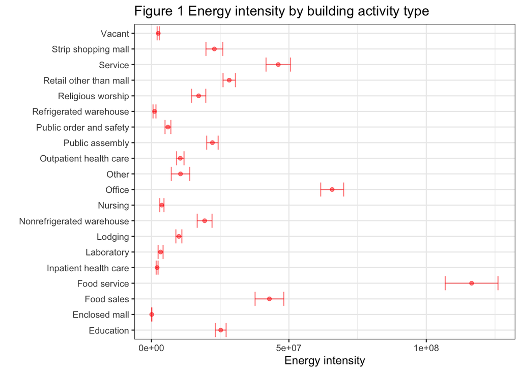

Figure 2 shows the energy intensity by different regions and building activity types. As we can see, for food sales, food service and office type of commercial buildings, the energy intensity shows a significant difference among different regions. On average, commercial buildings in the south region have larger major fuel consumption per square footage.

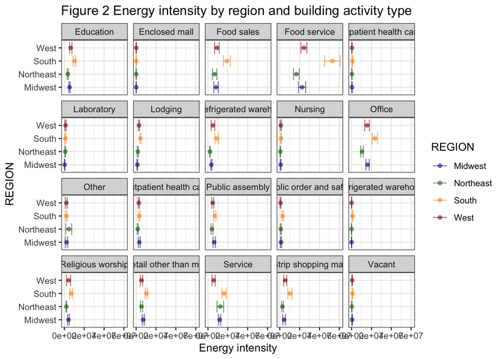

# Conclusion

In this project, I conducted a descriptive analysis on the 2012 CBECS data. The result shows that activity commercial building of the same type has different major fuel consumption intensities in different regions. Commercial buildings in the south region tend to have larger mean energy intensity.